# Intégrer des résultats de tests statistiques à des graphiques

[Retour à la page d’accueil](https://scortijo.github.io/2026_L3_R/)

Dans cette seconde partie de la section dédiée à la visualisation de données vous allez apprendre:

1. A intégrer des résultats de tests statistiques à des graphiques
2. Les meilleures pratiques pour visualiser des données

# Mise en place

Avant de rentrer dans le vif du sujet il nous faut mettre en place notre environnement de travail. Créez un nouveau script R et:

- chargez les librairies nécessaires:

```r
library(tidyverse)
```

```r
setwd("~/Desktop/2021_L3_R/session3_stats")
```

- Importez les données dans R:

```r
expt1 <- read_tsv("../data/burghardt_et_al_2015_expt1.txt")
```

Nous sommes maintenant prêt!

# 1.Intégrer des résultats de tests statistiques à des graphiques

## Les tests statistiques

Dans cette partie du cours vous allez découvrir ce qu’est un **test statistique** :

- A quoi sert un test statistique et comment interpréter son résultat?
- Comment choisir un test statistique approprié à ses données?
- Comment incorporer des tests statistiques à des graphiques ggplot?

### Principe des tests d’hypothèses

La création de connaissances dans le processus de recherche repose sur la **mise à l’épreuve d’hypothèses réfutables**.

Un des principaux outils d’un chercheur est de formaliser ses questionnements sous forme d’hypothèses, qui seront ensuite confrontées aux données générées pour y répondre. En effet, une observation “à l’œil” des données ou d’un graphique n’est pas une approche objective, reproductible, ni rigoureuse, pour faire des interprétations biologiques. **Les tests statistiques existent donc afin de fournir des métriques rigoureuses et impartiales aux expérimentateurs pour rejeter ou accepter des hypothèses de recherche.**

Imaginons que nous voulons savoir quel est l’effet de la longueur du jour (photopériode) sur le nombre de feuilles de rosettes d’Arabidopsis. Nous mettons donc en place une expérience dans laquelle nous exposons deux groupes de plantes à des conditions contrôlées, de manière à ce que la seule différence entre les deux groupes soit la longueur de la journée : jours courts ou jours longs.

Les graphes ci-dessous montrent le nombre de feuilles entre jours courts et jours longs pour deux écotypes différents d’Arabidopsis. Suivant les écotypes, il peut être difficile de dire si la longueur du jour a un réel effet, ou si les différences de moyennes sont uniquement dues à l’aléa, et à la variabilité du phénotype du nombre de feuilles entre les plantes :

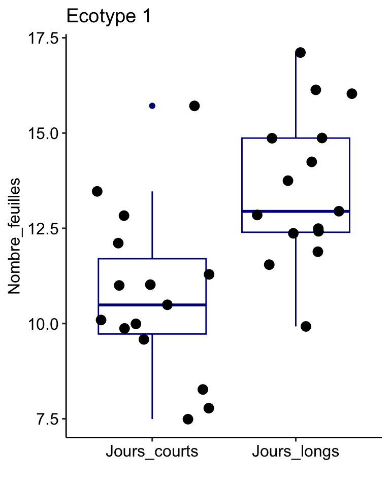

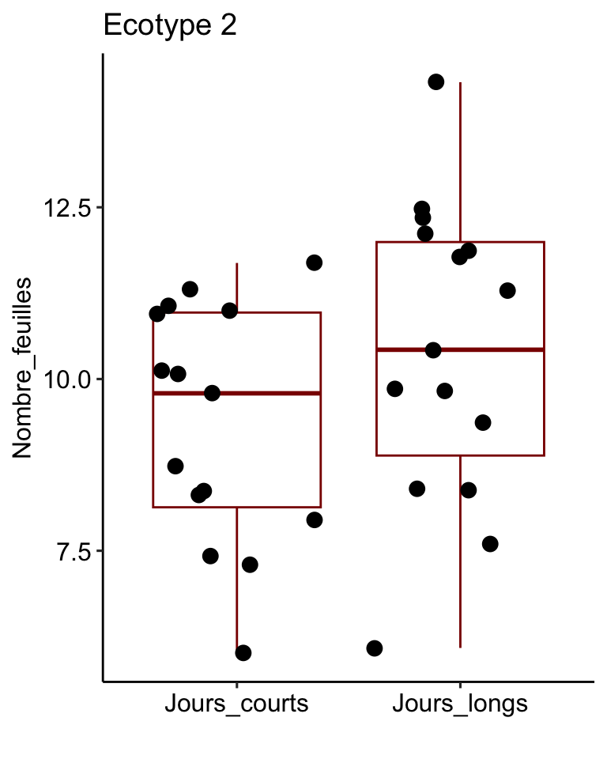

Nous pouvons donc tester si l’effet de la photopériode sur le nombre de feuilles est **significatif** au moyen d’un test statistique.

Un test statistique se déroule globalement en 4 étapes :

- **Définir une hypothèse nulle :** cette hypothèse représente souvent les effets aléatoires, l’absence d’effet d’un traitement, l’absence de différence entre deux groupes, on la qualifie parfois de l’hypothèse “ennuyeuse”. Dans notre cas, il s’agit d’une égalité de moyennes entre nos deux groupes, nous nous plaçons dans le cas ou la longueur de jour n’a pas d’effet sur le nombre de feuilles.
- **Calculer une statistique de test observée :** il s’agit d’une grandeur calculée sur les données, par exemple la différence de moyenne entre les deux longueurs de jours.
- **Comparer notre statistique de test observée à la distribution de cette statistique sous l’hypothèse nulle :** dans notre cas, il faut comparer la différence de moyennes entre jours courts et jours longs à la distribution des écarts de moyennes attendus sous l’hypothèse nulle (une distribution centrée en 0 car pas d’effet photopériode). Cela nous permet de calculer une **p-value** : la probabilité d’observer des données au moins aussi extrêmes que les nôtres sous l’hypothèse nulle. Dans notre exemple, il s’agit de la probabilité d’observer, sous l’hypothèse que la photopériode n’a pas d’effet, une telle différence de moyennes.
- **Conclure :** Si la p-value est très faible alors c’est que nos données sont très improbables sous l’hypothèse nulle, et donc qu’on peut se permettre de rejeter l’hypothèse nulle. Pour déterminer à partir de quand nous jugeons nos données suffisamment “improbables”, on fixe au préalable un seuil à notre test, traditionnellement 5%. Ce seuil établit que si on a moins de 5% de chances d’observer des données aussi extrêmes que les nôtres sous l’hypothèse nulle, alors on peut rejeter cette hypothèse. Dans notre cas, nous pourrons conclure à un effet **significative** de la longueur du jour sur le nombre de feuilles si la p-value du test est inférieure au seuil fixé.

Visualisons sur des graphes le calcul des p-values, via les valeurs observées de différences de moyennes pour les 2 écotypes. Ces différences de moyennes observées sont comparées à la distribution des écarts de moyennes sous l’hypothèse nulle (pas d’effet photopériode) :

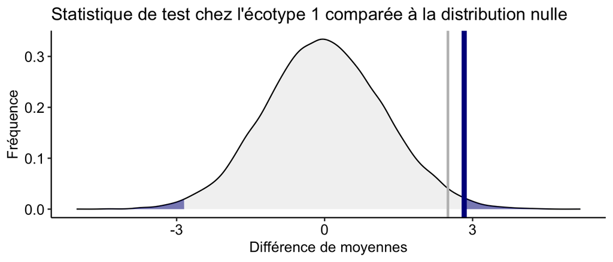

L’aire totale sous cette courbe vaut 1 car il s’agit d’une densité de probabilité, celle de l’écart de moyennes sous l’hypothèse nulle. Le trait vertical gris correspond à une valeur de différence de moyenne qui donnerait une p-value de 5%. La p-value correspond à l’aire colorée (la probabilité d’avoir une différence de moyennes au moins aussi extrême que nos données par rapport à l’hypothèse nulle). Elle est très faible, inférieure à 5%, car l’écart de moyennes important du cas 1 est assez extraordinaire sous l’hypothèse de non efficacité du traitement.

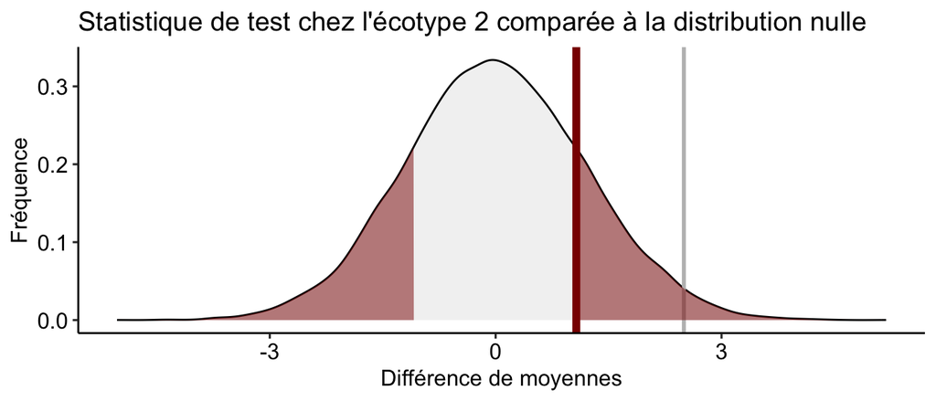

Ici, la p-value représentée par l’aire colorée a une valeur plus forte, supérieure à notre seuil de 5%, donc on ne pourra pas rejeter l’hypothèse que la photopériode n’a pas d’effet. Si on rajoute une p-value aux graphes présentés plus haut, on obtient :

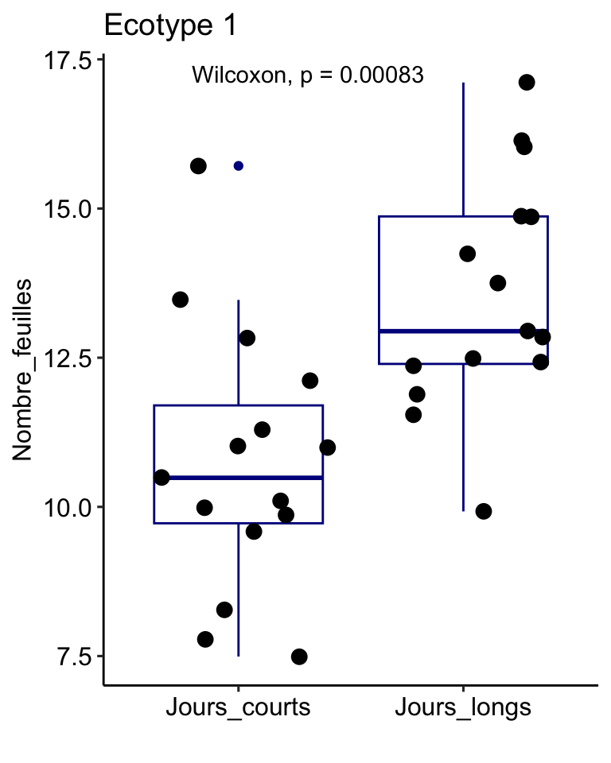

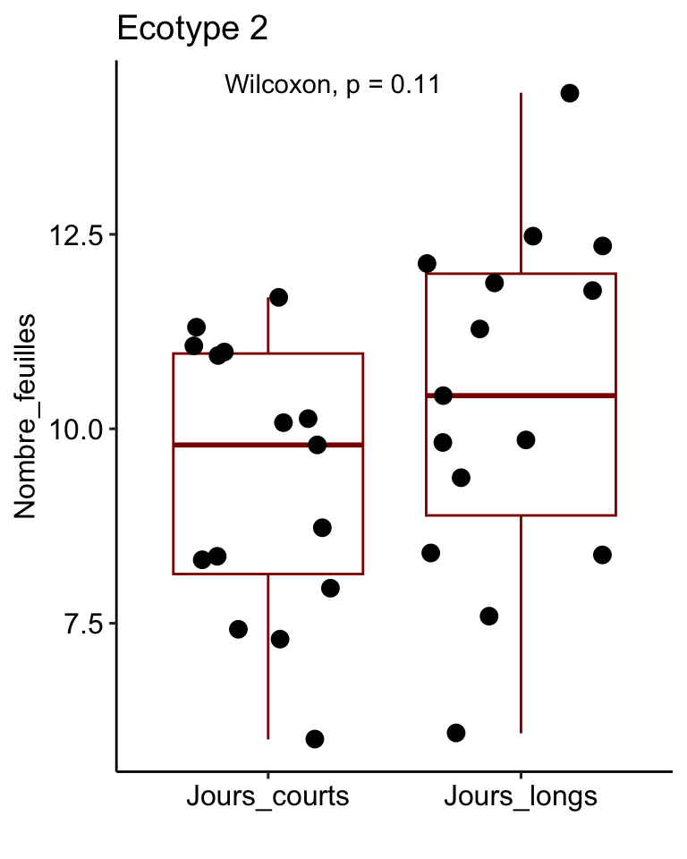

**L’écotype 1 est sensible à une différence de photopériode de manière significative, alors que l’écotype 2 ne semble pas l’être.**

Le test de comparaison de moyennes réalisé ici est le `wilcox.test`. Comment choisir le test à réaliser suivant nos données?

### Choisir un test statistique

Suivant le type des données et les hypothèses que l’on peut vérifier sur les données, il faut choisir un test statistique adapté. Globalement, il existe deux types de tests : les **paramétriques** (qui requirent de vérifier un certain nombre d’hypothèses sur les données) et les tests **non paramétriques** (qui ne sont pas soumis à la vérification d’hypothèses, mais au détriment d’une perte de puissance statistique, c’est à dire la capacité du test à détecter un effet lorsqu’il y en a bien un).

**Cas d’une variable numérique (c’est à dire quantitative) et d’une variable catégorielle (c’est à dire qualitative)**:

- Si on a deux groupes pour lesquels on a mesuré une grandeur numérique (quantitative), on peut réaliser un test de comparaison de moyennes. Son hypothèse nulle est que les moyennes des deux groupes sont égales. Si la p-value est significative, cela veut dire que les 2 groupes ont des moyennes significativement différentes. Usuellement, c’est le **T-test** qui est utilisé, un test paramétrique de comparaison de moyennes. Si les échantillons sont de petite taille, que les données ne suivent pas une loi normale, ou que les variances des groupes ont l’air trop différentes, les hypothèses du T-test ne sont pas respectées et on utilisera plutôt son alternative non paramétrique, le **Wilcox-test**.
- Si on a plus de deux groupes, on peut réaliser une analyse de la variance. Son hypothèse nulle est que les moyennes de tous les groupes sont les mêmes. Si la p-value est significative, cela veut dire qu’au moins un groupe a une moyenne différente des autres. Usuellement, c’est l’ **ANOVA** qui est utilisée, un test paramétrique de comparaison de plusieurs moyennes. Si les échantillons sont de petite taille, que les données ne suivent pas une loi normale, ou que les variances des groupes ont l’air trop différentes les hypothèses de l’ANOVA ne sont pas respectées et on utilisera plutôt son alternative non paramétrique, le **Kruskal-Wallis-Test**.

*Note : on peut vérifier la normalité des données au moyen du test de shapiro :* `shapiro.test()`

**Cas de deux variables numériques (quantitatives)**:

On pourrait par exemple vouloir tester l’effet de la teneur en nitrate, une valeur continue, sur la biomasse des plantes. Dans ce cas là, on peut tester si le coefficient de corrélation calculé entre ces deux variables est significatif ou non. Le coefficient de corrélation $R$, avec $-1 \leq R \leq 1$, quantifie la force de la relation entre deux variables. Plus la valeur absolue de $R$ est grande, plus les variables sont corrélées, et auront tendance à toujours évoluer conjointement. Si $R<0$, les deux variables ont une relation inverse. La p-value de ce test permet de rejeter ou non l’hypothèse nulle, qui est l’absence de corrélation entre les deux variables ($R=0$).

*Note: Il existe les coefficients de corrélation de `pearson` (paramétrique, pour des données normales ou de grande taille) ou de `spearman` (pour des données non normales et avec une faible taille d’échantillon)*. Il convient d’utiliser la méthode la plus adaptée en fonction des données.

**Autres cas**:

Il existe également beaucoup d’autres tests, comme des tests de comparaison de variance (établir si deux groupes ont des dispersion différentes), des tests de comparaison de proportions, des tests d’indépendance, des tests sur les distributions, et il convient de faire des recherches au préalable, avant de déterminer votre plan expérimental, pour savoir quels tests existants sont les plus adaptés à votre question et à vos données.

Quelques lien vers des listes de tests statistiques et leurs cas d’application :

- https://doc.dataiku.com/dss/latest/statistics/tests.html
- https://www.scribbr.com/statistics/statistical-tests/
- https://lantsandlaminins.com/statistics-test-flow-chart/

Dans ce cours, et ses applications, nous allons uniquement nous concentrer sur des tests de corrélation et de comparaison de moyennes.

### Bien utiliser un test statistique

Une fois que vous connaissez le test à utiliser suivant la nature des données, que vous avez vérifié ses hypothèses, restez très vigilants à plusieurs points :

- **Le nombre d’observations** est un élément crucial pour un test. Si le nombre d’observations est trop faible, la puissance statistique du test est très basse (c’est à dire sa capacité à détecter un effet lorsqu’il y en a bien un). Des tests sur faibles effectifs sont donc difficiles voire impossible à interpréter. Dans ces cas là est plutôt conseillé de ne pas faire d’interprétations fortes, mais plutôt de refaire des expériences pour augmenter le nombre d’observations.
- **La significativité d’un test de comparaison de moyennes ou d’un test de corrélation ne signifie pas qu’il y a causalité entre les deux variables étudiées**. Il faut être précautionneux et raisonnable dans les interprétation en fonction de votre plan expérimental.

## Ajouter des résultats de tests statistiques à des graphiques

Pour pouvoir rajouter des résultats de tests statistiques à des graphiques, nous allons utiliser des fonctions de la librairie `ggpubr`.

```r
library(ggpubr)
```

### Comparaison de moyennes de deux (ou plusieurs) groupes

Afin de faire un test de comparaison de moyennes, nous utilisons la fonction `stat_compare_means`.

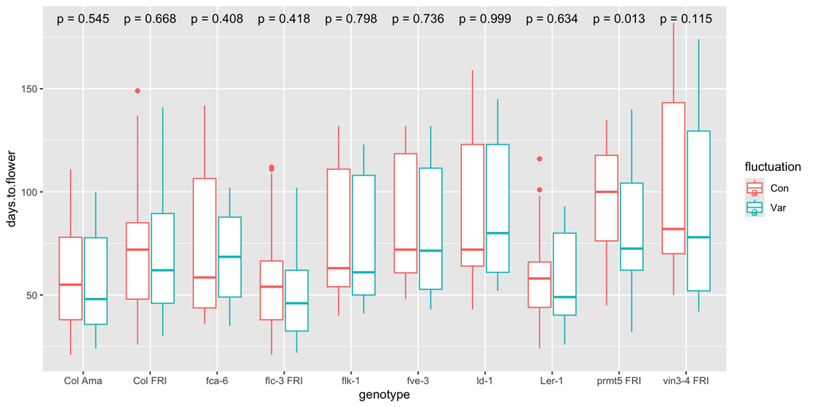

```r
ggplot(expt1, aes(genotype, days.to.flower, colour = fluctuation)) +
  geom_boxplot() +
  stat_compare_means(label = "p.format", method="t.test")
```

Comme nous avons deux groupes à comparer (température fluctuante vs température constante), la fonction fait la comparaison de ces deux groupes automatiquement pour chaque génotype et donne la p-value associée.

Plutôt que d’ajouter les valeurs des p-values, il est aussi possible d’utiliser un code à base d’étoiles pour indiquer le niveau de significativité du test:

ns: p > 0.05

*: p <= 0.05

**: p <= 0.01

***: p <= 0.001

****: p <= 0.0001

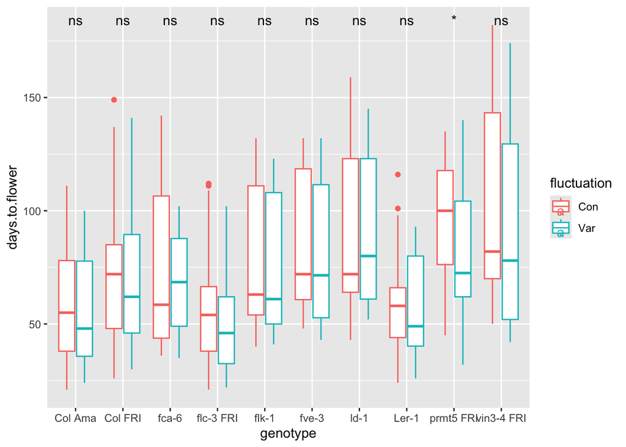

```r
ggplot(expt1, aes(genotype, days.to.flower, colour = fluctuation)) +
  geom_boxplot() +
  stat_compare_means(label = "p.signif", method="t.test")
```

Par contre, s’il n’y a pas deux groupes clairement identifiés, tous les groupes vont être comparés, en utilisant par défaut avec un test de Kruskal–Wallis:

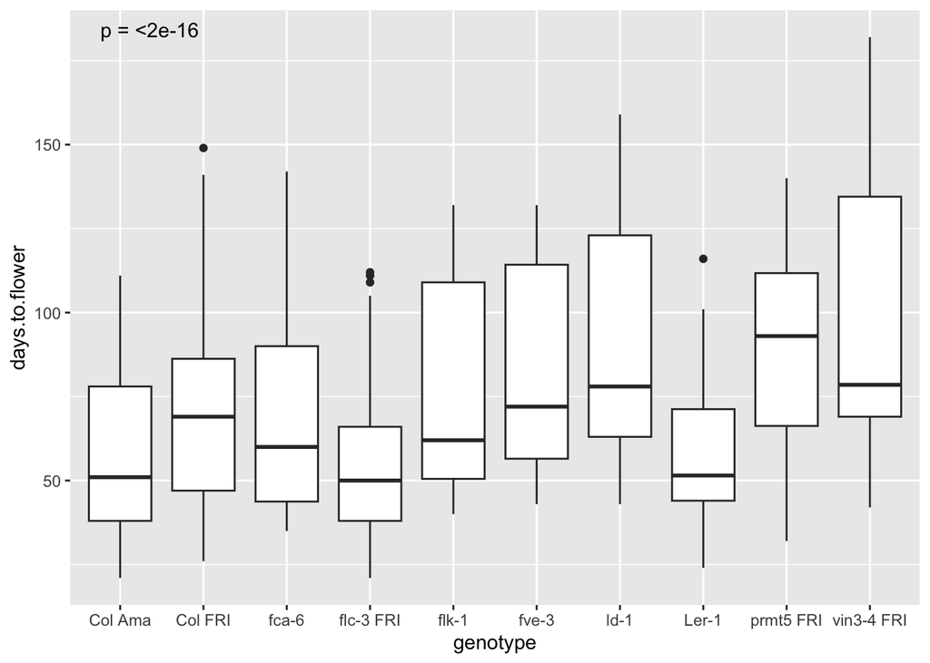

```r
ggplot(expt1, aes(genotype, days.to.flower)) +
  geom_boxplot() +
  stat_compare_means(label = "p.format")
```

Voir [ce site](http://www.sthda.com/english/articles/24-ggpubr-publication-ready-plots/76-add-p-values-and-significance-levels-to-ggplots/) pour en savoir plus sur les différentes options de tests de comparaison de moyennes (comparaison de deux groupes et de multiples groupes).

### Tests de corrélation

Il est aussi possible d’ajouter le résultat d’un test de corrélation (spearman ou pearson) à un scatterplot en utilisant la fonction `stat_cor()`:

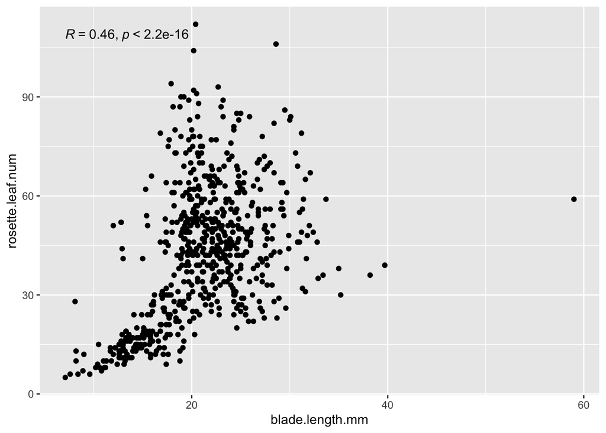

```r
ggplot(expt1, aes(blade.length.mm, rosette.leaf.num)) +
    geom_point()+
  stat_cor()
```

Par défaut, un test de `pearson` est effectué. Pour utiliser un test de `spearman`, il faut utiliser `method="spearman"`

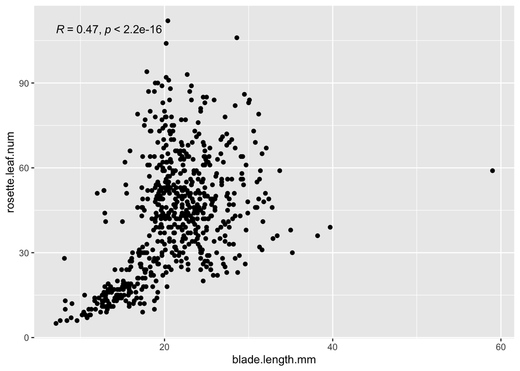

```r
ggplot(expt1, aes(blade.length.mm, rosette.leaf.num)) +
    geom_point()+
  stat_cor(method="spearman")
```

Si vous avez plusieurs groupes, `stat_cor` va calculer la corrélation pour chaque groupe.

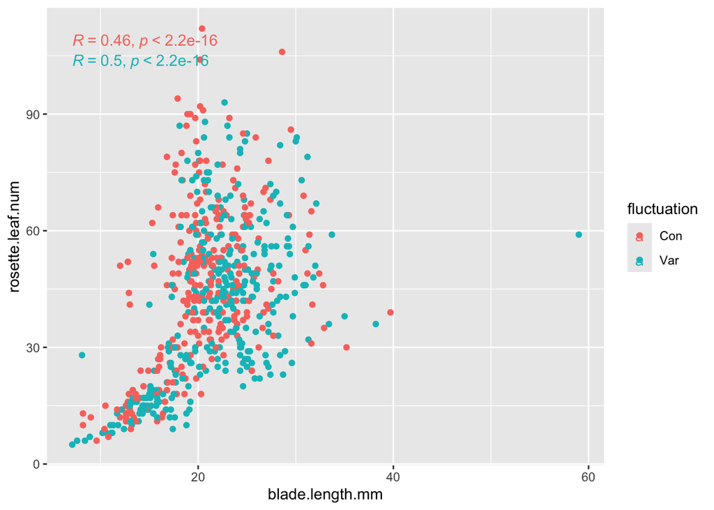

```r
ggplot(expt1, aes(blade.length.mm, rosette.leaf.num, colour = fluctuation)) +
    geom_point()+
  stat_cor()
```

Il est aussi possible d’ajouter une ligne de régression (linéaire ou non), incluant un intervalle de confiance, au graphique avec `geom_smooth()`. Notez cependant, comme on peut le voir ci-dessous, que cette fonction fonctionne mieux pour des régressions linéaires et non complexes.

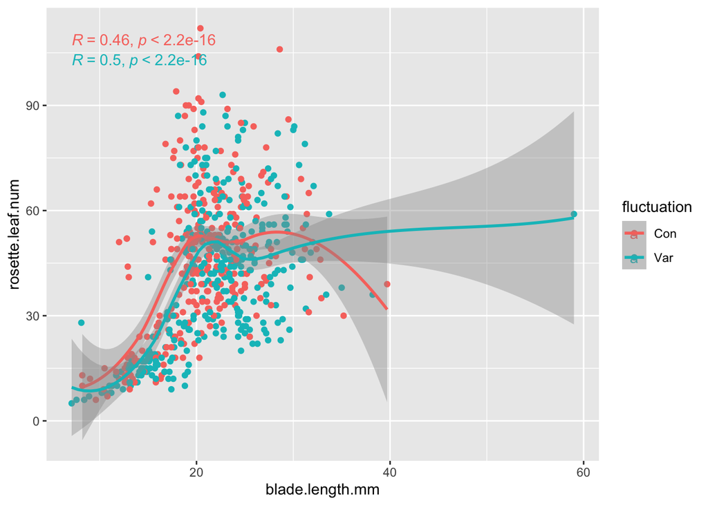

```r
ggplot(expt1, aes(blade.length.mm, rosette.leaf.num, colour = fluctuation)) +
    geom_point()+
  stat_cor() +
  geom_smooth()
```

Comme vous pouvez le voir, la ligne de régression ne représente pas bien les données. Il faudrait ici utiliser une méthode plus compliquée pour pouvoir extrapoler une ligne de régression. Ce n’est pas parce qu’il est possible de faire quelque chose avec R, que cela est forcément judicieux. Soyez critique et assurez vous que ce que vous faites soit pertinent!

> **Exercice 1:**

> Ajouter le test statistique le plus approprié aux deux graphiques suivant:

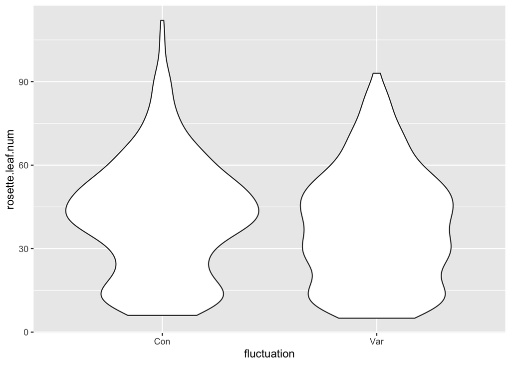

```r
ggplot(expt1, aes(fluctuation, rosette.leaf.num)) +
  geom_violin()
```

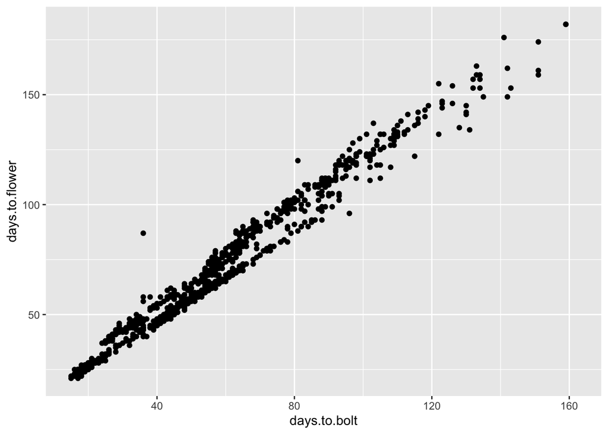

```r
ggplot(expt1, aes(days.to.bolt, days.to.flower)) +
    geom_point()
```

> **BONUS:** Ajoutez une ligne de régression (pour le graphique où cela est possible). Déplacez le résultat du test statistique pour qu’il soit au meilleur endroit sur le graphique. Qu’est ce que vous pouvez conclure pour chacun de ces graphiques?

# 2.Bonnes pratiques de visualisation de données

## Trouver le graphique approprié à vos données et à votre question

Utiliser le graphique approprié à nos données et répondant à notre question est essentiel. Cependant cela n’est pas toujours intuitif et dépend:

- **Du type de données**. S’agit t-il de nombres ou de catégories, ou d’une combinaison des deux? Ou bien de séries chronologique?

-**Du nombre de variable à représenter**. Voulez vous montrer une seule variable ou plusieurs? Et s’il y en a deux, voulez vous les comparer directement (dans le cas de nombres)

Comme il existe de nombreuses options, utilisez [ce guide avec un arbre de décision](https://www.data-to-viz.com/) pour choisir la meilleure méthode de visualisation

> **Discussion de groupe**

> Discutez avec votre voisin des deux types de graphique suivant.

> Les avez vous déjà utilisés? Si oui, pour représenter quel type de données?

> Sont ils appropriés à vos données et à votre question? Si non, quel autre type de graphique utiliseriez vous maintenant que vous savez utiliser ggplot?

> **1. Le camembert (pie chart)**

> Aidez vous de cette figure comparant des camemberts et des barplots montrant les mêmes données

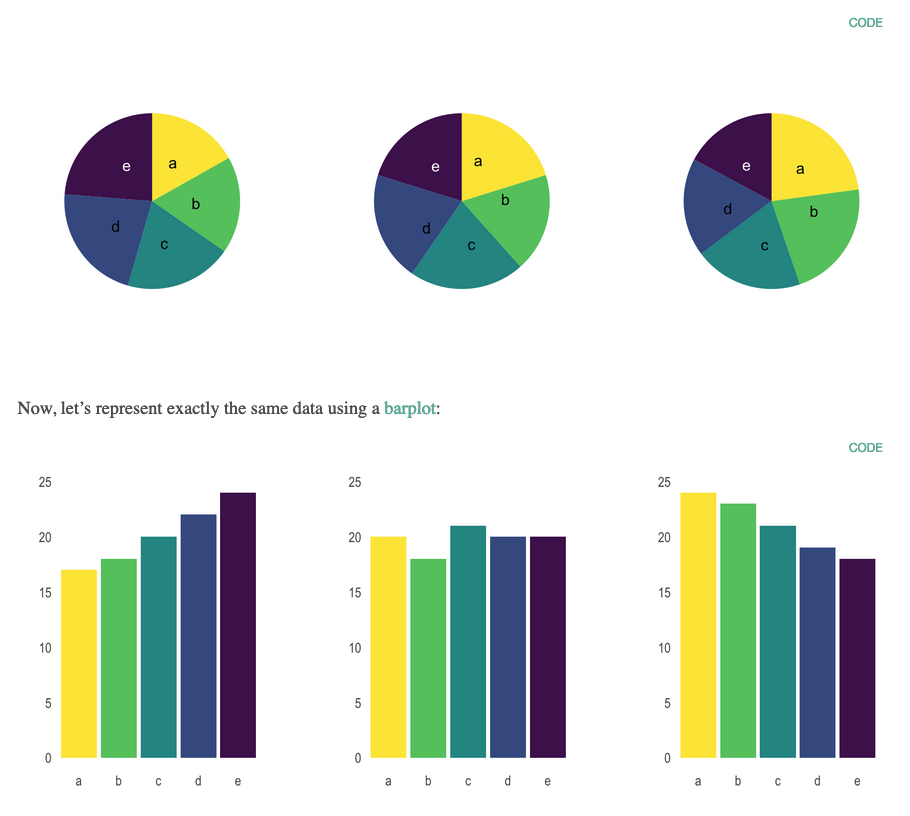

> [source de l’image](https://www.data-to-viz.com/caveat/pie.html)

> **2. Le barplot avec des barres d’erreur**

> Les barplots avec barre d’erreur permettent de représenter la moyenne d’une population (barplot) ainsi que la dispersion des données (barre d’erreur).

> Mais est-ce idéal pour montrer nos données? Discutez en avec votre voisin en vous aidant de la figure ci-dessous extraite de [Weissgerber et al., 2015](https://journals.plos.org/plosbiology/article?id=10.1371/journal.pbio.1002128).

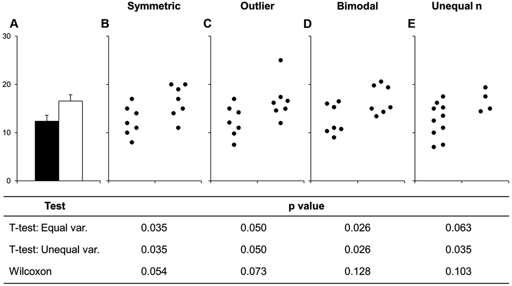